# Introduction

"In vino veritas" - Pline l'Ancien

Ce projet a pour but de satisfaire ma curiosité sur un thème que j'affectionne particulièrement : le bon vin !  
Thèmes généraux :  
Nature / Ecologie / Environnement  
Agronomie / Agriculture / Agroindustrie  
Viniculture / Qualité  
Le jeu de données utilisé présente différents paramètres physico-chimiques mesurés après les étapes de vinification ainsi qu'une évaluation organoleptique correspondant à la qualité du vin testé.  
Problématiques :  
-Est-il possible de prédire la qualité d'un vin avant de le goûter ?  
-Quels sont les paramètres à prendre en compte ?  
-Comment déterminer l'importance / l'influence de ces paramètres sur la qualité d'un vin ?

## Préparation des données

Import des librairies

```python
import numpy as np
import pandas as pd
import matplotlib.pyplot as plt
import seaborn as sns
from sklearn.model_selection import train_test_split
from sklearn.pipeline import Pipeline
from sklearn.compose import ColumnTransformer
from sklearn.pipeline import make_pipeline
from sklearn.preprocessing import MinMaxScaler
from sklearn.preprocessing import StandardScaler
from sklearn.preprocessing import OneHotEncoder
from sklearn.impute import SimpleImputer
from sklearn.linear_model import LinearRegression
from sklearn.linear_model import Ridge
from sklearn.linear_model import Lasso

from sklearn.compose import make_column_selector as selector
from sklearn import set_config
set_config(display="diagram")
from sklearn.model_selection import cross_val_score
from sklearn.model_selection import cross_validate
import statsmodels.api as sm
import statsmodels.stats.api as sms
from statsmodels.compat import lzip
import pickle

import patsy
import patsylearn
```

Chargement du dataset

```python
df = pd.read_csv('winequality-red.csv')
```

Observation des données

```python
df.head(8)
```

|  | fixed acidity | volatile acidity | citric acid | residual sugar | chlorides | free sulfur dioxide | total sulfur dioxide | density | pH | sulphates | alcohol | quality |
| --- | --- | --- | --- | --- | --- | --- | --- | --- | --- | --- | --- | --- |
| 0 | 7.4 | 0.70 | 0.00 | 1.9 | 0.076 | 11.0 | 34.0 | 0.9978 | 3.51 | 0.56 | 9.4 | 5 |
| 1 | 7.8 | 0.88 | 0.00 | 2.6 | 0.098 | 25.0 | 67.0 | 0.9968 | 3.20 | 0.68 | 9.8 | 5 |
| 2 | 7.8 | 0.76 | 0.04 | 2.3 | 0.092 | 15.0 | 54.0 | 0.9970 | 3.26 | 0.65 | 9.8 | 5 |
| 3 | 11.2 | 0.28 | 0.56 | 1.9 | 0.075 | 17.0 | 60.0 | 0.9980 | 3.16 | 0.58 | 9.8 | 6 |
| 4 | 7.4 | 0.70 | 0.00 | 1.9 | 0.076 | 11.0 | 34.0 | 0.9978 | 3.51 | 0.56 | 9.4 | 5 |
| 5 | 7.4 | 0.66 | 0.00 | 1.8 | 0.075 | 13.0 | 40.0 | 0.9978 | 3.51 | 0.56 | 9.4 | 5 |
| 6 | 7.9 | 0.60 | 0.06 | 1.6 | 0.069 | 15.0 | 59.0 | 0.9964 | 3.30 | 0.46 | 9.4 | 5 |
| 7 | 7.3 | 0.65 | 0.00 | 1.2 | 0.065 | 15.0 | 21.0 | 0.9946 | 3.39 | 0.47 | 10.0 | 7 |

```python
df.tail()
```

|  | fixed acidity | volatile acidity | citric acid | residual sugar | chlorides | free sulfur dioxide | total sulfur dioxide | density | pH | sulphates | alcohol | quality |
| --- | --- | --- | --- | --- | --- | --- | --- | --- | --- | --- | --- | --- |
| 1594 | 6.2 | 0.600 | 0.08 | 2.0 | 0.090 | 32.0 | 44.0 | 0.99490 | 3.45 | 0.58 | 10.5 | 5 |
| 1595 | 5.9 | 0.550 | 0.10 | 2.2 | 0.062 | 39.0 | 51.0 | 0.99512 | 3.52 | 0.76 | 11.2 | 6 |
| 1596 | 6.3 | 0.510 | 0.13 | 2.3 | 0.076 | 29.0 | 40.0 | 0.99574 | 3.42 | 0.75 | 11.0 | 6 |
| 1597 | 5.9 | 0.645 | 0.12 | 2.0 | 0.075 | 32.0 | 44.0 | 0.99547 | 3.57 | 0.71 | 10.2 | 5 |
| 1598 | 6.0 | 0.310 | 0.47 | 3.6 | 0.067 | 18.0 | 42.0 | 0.99549 | 3.39 | 0.66 | 11.0 | 6 |

```python
df.info()
```

```
<class 'pandas.core.frame.DataFrame'>
RangeIndex: 1599 entries, 0 to 1598
Data columns (total 12 columns):
 #   Column                Non-Null Count  Dtype
---  ------                --------------  -----
 0   fixed acidity         1599 non-null   float64
 1   volatile acidity      1599 non-null   float64
 2   citric acid           1599 non-null   float64
 3   residual sugar        1599 non-null   float64
 4   chlorides             1599 non-null   float64
 5   free sulfur dioxide   1599 non-null   float64
 6   total sulfur dioxide  1599 non-null   float64
 7   density               1599 non-null   float64
 8   pH                    1599 non-null   float64
 9   sulphates             1599 non-null   float64
 10  alcohol               1599 non-null   float64
 11  quality               1599 non-null   int64
dtypes: float64(11), int64(1)
memory usage: 150.0 KB
```

```python
df.describe()
```

|  | fixed acidity | volatile acidity | citric acid | residual sugar | chlorides | free sulfur dioxide | total sulfur dioxide | density | pH | sulphates | alcohol | quality |
| --- | --- | --- | --- | --- | --- | --- | --- | --- | --- | --- | --- | --- |
| count | 1599.000000 | 1599.000000 | 1599.000000 | 1599.000000 | 1599.000000 | 1599.000000 | 1599.000000 | 1599.000000 | 1599.000000 | 1599.000000 | 1599.000000 | 1599.000000 |
| mean | 8.319637 | 0.527821 | 0.270976 | 2.538806 | 0.087467 | 15.874922 | 46.467792 | 0.996747 | 3.311113 | 0.658149 | 10.422983 | 5.636023 |
| std | 1.741096 | 0.179060 | 0.194801 | 1.409928 | 0.047065 | 10.460157 | 32.895324 | 0.001887 | 0.154386 | 0.169507 | 1.065668 | 0.807569 |
| min | 4.600000 | 0.120000 | 0.000000 | 0.900000 | 0.012000 | 1.000000 | 6.000000 | 0.990070 | 2.740000 | 0.330000 | 8.400000 | 3.000000 |
| 25% | 7.100000 | 0.390000 | 0.090000 | 1.900000 | 0.070000 | 7.000000 | 22.000000 | 0.995600 | 3.210000 | 0.550000 | 9.500000 | 5.000000 |
| 50% | 7.900000 | 0.520000 | 0.260000 | 2.200000 | 0.079000 | 14.000000 | 38.000000 | 0.996750 | 3.310000 | 0.620000 | 10.200000 | 6.000000 |
| 75% | 9.200000 | 0.640000 | 0.420000 | 2.600000 | 0.090000 | 21.000000 | 62.000000 | 0.997835 | 3.400000 | 0.730000 | 11.100000 | 6.000000 |
| max | 15.900000 | 1.580000 | 1.000000 | 15.500000 | 0.611000 | 72.000000 | 289.000000 | 1.003690 | 4.010000 | 2.000000 | 14.900000 | 8.000000 |

```python
df.isnull().any()
```

```
fixed acidity           False
volatile acidity        False
citric acid             False
residual sugar          False
chlorides               False
free sulfur dioxide     False
total sulfur dioxide    False
density                 False
pH                      False
sulphates               False
alcohol                 False
quality                 False
dtype: bool
```

```python
df.duplicated().any()
```

```
True
```

```python
df_clean = df.drop_duplicates()
```

```python
df_clean.describe()
```

|  | fixed acidity | volatile acidity | citric acid | residual sugar | chlorides | free sulfur dioxide | total sulfur dioxide | density | pH | sulphates | alcohol | quality |
| --- | --- | --- | --- | --- | --- | --- | --- | --- | --- | --- | --- | --- |
| count | 1359.000000 | 1359.000000 | 1359.000000 | 1359.000000 | 1359.000000 | 1359.000000 | 1359.000000 | 1359.000000 | 1359.000000 | 1359.000000 | 1359.000000 | 1359.000000 |
| mean | 8.310596 | 0.529478 | 0.272333 | 2.523400 | 0.088124 | 15.893304 | 46.825975 | 0.996709 | 3.309787 | 0.658705 | 10.432315 | 5.623252 |
| std | 1.736990 | 0.183031 | 0.195537 | 1.352314 | 0.049377 | 10.447270 | 33.408946 | 0.001869 | 0.155036 | 0.170667 | 1.082065 | 0.823578 |
| min | 4.600000 | 0.120000 | 0.000000 | 0.900000 | 0.012000 | 1.000000 | 6.000000 | 0.990070 | 2.740000 | 0.330000 | 8.400000 | 3.000000 |
| 25% | 7.100000 | 0.390000 | 0.090000 | 1.900000 | 0.070000 | 7.000000 | 22.000000 | 0.995600 | 3.210000 | 0.550000 | 9.500000 | 5.000000 |
| 50% | 7.900000 | 0.520000 | 0.260000 | 2.200000 | 0.079000 | 14.000000 | 38.000000 | 0.996700 | 3.310000 | 0.620000 | 10.200000 | 6.000000 |
| 75% | 9.200000 | 0.640000 | 0.430000 | 2.600000 | 0.091000 | 21.000000 | 63.000000 | 0.997820 | 3.400000 | 0.730000 | 11.100000 | 6.000000 |
| max | 15.900000 | 1.580000 | 1.000000 | 15.500000 | 0.611000 | 72.000000 | 289.000000 | 1.003690 | 4.010000 | 2.000000 | 14.900000 | 8.000000 |

Globalement, le dataset est "propre". Il est constitué de 1599 échantillons et 12 colonnes caractéristiques.  
Les observations portent sur des quantités mesurées (d'acidité, de sucre, de minéraux, d'additifs résiduels, du taux d'alcool), mesure du pH et de la densité, ainsi qu'un score attribué entre 0 et 10.  
Il n'y a pas de valeur manquante. Le type de données est uniquement numérique (soit float, soit integer). Je note la présence de 240 doublons qui après éliminations laissent le jeu de données avec 1359 échantillons.

Visualisation des données

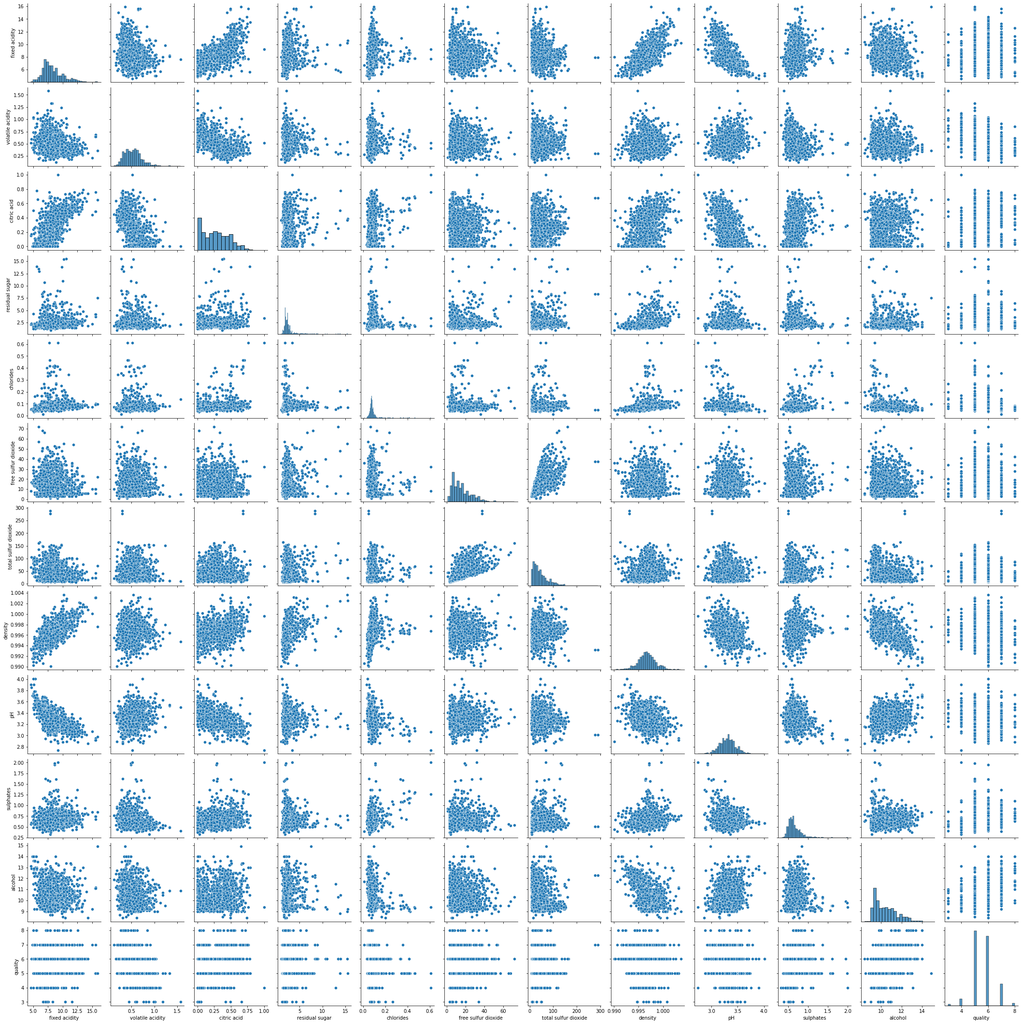

```python
sns.pairplot(df_clean)
plt.show()
```

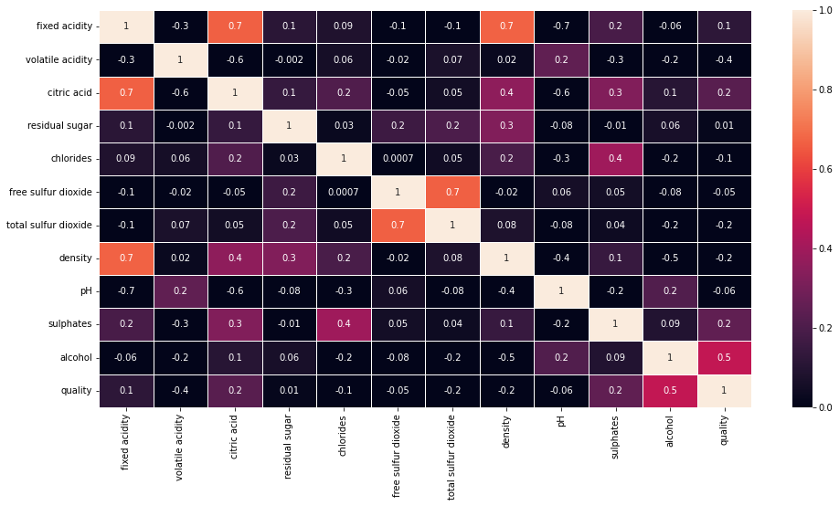

```python
plt.figure(figsize=(16,8))
sns.heatmap(df_clean.corr(), annot=True,linewidth=.5, fmt='.1g', vmin=0)
plt.show()
```

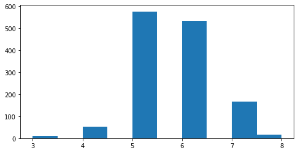

```python
plt.figure(figsize=(8, 4))
plt.hist(df_clean['quality'])
plt.show();
```

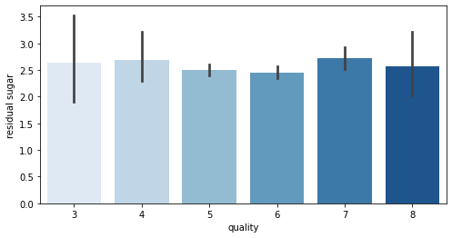

```python
plt.figure(figsize=(8, 4))
sns.barplot(x='quality', y='residual sugar', data = df_clean, palette='Blues')
plt.show()
```

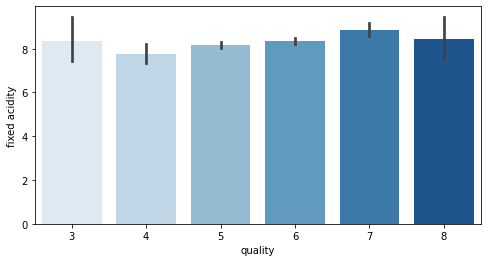

```python
plt.figure(figsize=(8, 4))
sns.barplot(x='quality', y='fixed acidity', data = df_clean, palette='Blues')
plt.show()
```

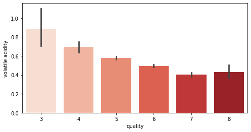

```python
plt.figure(figsize=(8, 4))
sns.barplot(x='quality', y='volatile acidity', data = df_clean, palette='Reds')
plt.show()
```

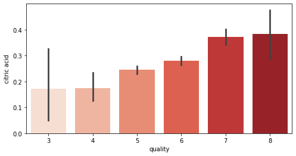

```python
plt.figure(figsize=(8, 4))
sns.barplot(x='quality', y='citric acid', data = df_clean, palette='Reds')
plt.show()
```

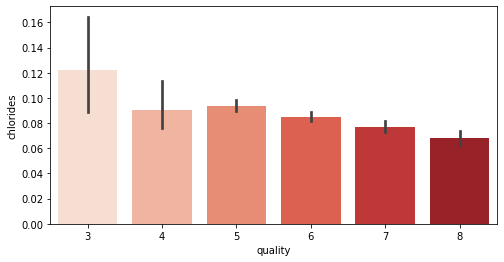

```python
plt.figure(figsize=(8, 4))
sns.barplot(x='quality', y='chlorides', data = df_clean, palette='Reds')
plt.show()
```

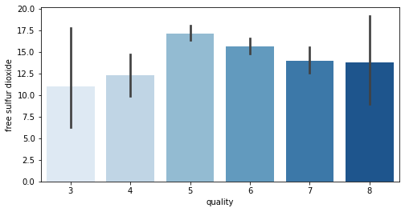

```python
plt.figure(figsize=(8, 4))
sns.barplot(x='quality', y='free sulfur dioxide', data = df_clean, palette='Blues')
plt.show()
```

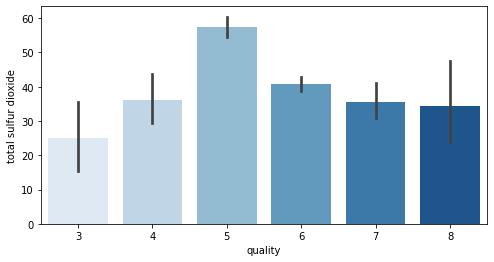

```python
plt.figure(figsize=(8, 4))
sns.barplot(x='quality', y='total sulfur dioxide', data = df_clean, palette='Blues')
plt.show()
```

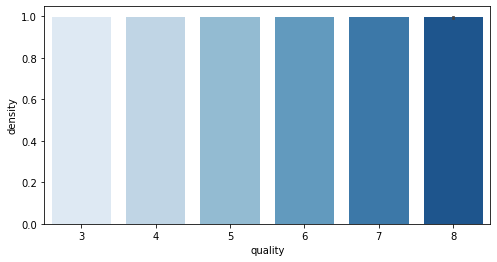

```python
plt.figure(figsize=(8, 4))
sns.barplot(x='quality', y='density', data = df_clean, palette='Blues')
plt.show()
```

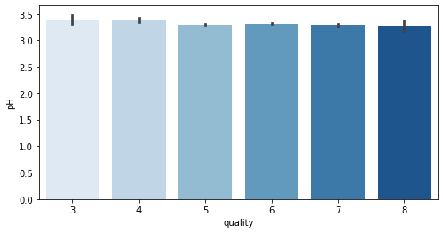

```python
plt.figure(figsize=(8, 4))
sns.barplot(x='quality', y='pH', data = df_clean, palette='Blues')
plt.show()
```

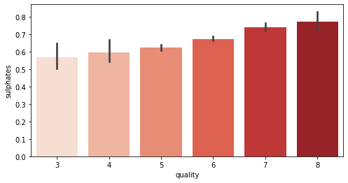

```python
plt.figure(figsize=(8, 4))
sns.barplot(x='quality', y='sulphates', data = df_clean, palette='Reds')
plt.show()
```

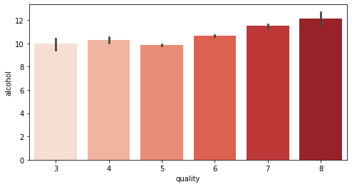

```python
plt.figure(figsize=(8, 4))
sns.barplot(x='quality', y='alcohol', data = df_clean, palette='Reds')
plt.show()
```

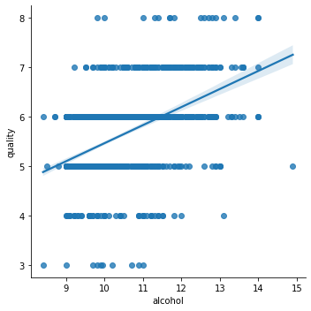

```python
sns.lmplot(x='alcohol',y='quality',data=df_clean)
plt.show()
```

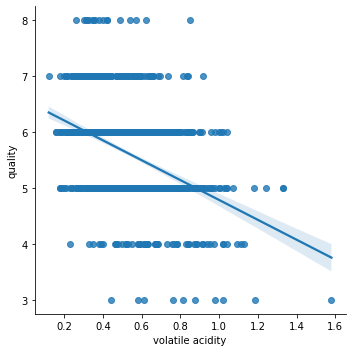

```python
sns.lmplot(x='volatile acidity',y='quality',data=df_clean)
plt.show()
```

Transformation du dataset

```python
df_clean.columns
```

```
Index(['fixed acidity', 'volatile acidity', 'citric acid', 'residual sugar',
       'chlorides', 'free sulfur dioxide', 'total sulfur dioxide', 'density',
       'pH', 'sulphates', 'alcohol', 'quality'],
      dtype='object')
```

```python
df_sample = {'fixed acidity': 0, 'volatile acidity': 0, 'citric acid': 0, 'residual sugar': 0,
       'chlorides': 0, 'free sulfur dioxide': 0, 'total sulfur dioxide': 0, 'density': 0,
       'pH': 0, 'sulphates': 0, 'alcohol': 0, 'quality': 0}
df_sample = pd.DataFrame([df_sample])
```

```python
for i in range(0, 1500):
    sub_df = df_clean.sample(n=3).mean()
    sub_df = pd.DataFrame(sub_df).transpose()
    df_sample = pd.concat([df_sample, sub_df])
```

```python
df_sample = df_sample.iloc[1:]
df_sample
```

|  | fixed acidity | volatile acidity | citric acid | residual sugar | chlorides | free sulfur dioxide | total sulfur dioxide | density | pH | sulphates | alcohol | quality |
| --- | --- | --- | --- | --- | --- | --- | --- | --- | --- | --- | --- | --- |
| 0 | 7.600000 | 0.543333 | 0.310000 | 2.466667 | 0.109000 | 12.333333 | 31.000000 | 0.996280 | 3.340000 | 0.560000 | 9.900000 | 5.000000 |
| 0 | 8.166667 | 0.413333 | 0.303333 | 2.066667 | 0.075333 | 14.000000 | 42.333333 | 0.995827 | 3.330000 | 0.610000 | 11.000000 | 6.333333 |
| 0 | 6.333333 | 0.521667 | 0.106667 | 2.000000 | 0.083000 | 11.000000 | 48.000000 | 0.995713 | 3.406667 | 0.486667 | 9.766667 | 4.666667 |
| 0 | 7.666667 | 0.613333 | 0.083333 | 2.900000 | 0.086667 | 9.666667 | 51.000000 | 0.997313 | 3.263333 | 0.543333 | 9.433333 | 5.000000 |
| 0 | 7.866667 | 0.430000 | 0.213333 | 2.200000 | 0.078667 | 7.666667 | 24.666667 | 0.996683 | 3.353333 | 0.673333 | 10.200000 | 6.000000 |
| ... | ... | ... | ... | ... | ... | ... | ... | ... | ... | ... | ... | ... |
| 0 | 9.266667 | 0.460000 | 0.353333 | 2.000000 | 0.076667 | 9.000000 | 39.666667 | 0.998033 | 3.300000 | 0.620000 | 9.800000 | 5.666667 |
| 0 | 8.200000 | 0.463333 | 0.196667 | 3.500000 | 0.088333 | 20.666667 | 49.666667 | 0.997327 | 3.306667 | 0.626667 | 10.133333 | 5.666667 |
| 0 | 8.966667 | 0.563333 | 0.233333 | 1.833333 | 0.083667 | 17.333333 | 42.666667 | 0.995517 | 3.173333 | 0.776667 | 10.900000 | 5.666667 |
| 0 | 9.233333 | 0.448333 | 0.456667 | 2.600000 | 0.190333 | 19.000000 | 64.000000 | 0.997840 | 3.183333 | 0.850000 | 9.633333 | 5.666667 |
| 0 | 8.033333 | 0.735000 | 0.196667 | 2.366667 | 0.068667 | 15.333333 | 41.666667 | 0.995633 | 3.296667 | 0.583333 | 11.266667 | 5.666667 |

1500 rows × 12 columns

```python
df_sample.reset_index(drop=True)
```

|  | fixed acidity | volatile acidity | citric acid | residual sugar | chlorides | free sulfur dioxide | total sulfur dioxide | density | pH | sulphates | alcohol | quality |
| --- | --- | --- | --- | --- | --- | --- | --- | --- | --- | --- | --- | --- |
| 0 | 7.600000 | 0.543333 | 0.310000 | 2.466667 | 0.109000 | 12.333333 | 31.000000 | 0.996280 | 3.340000 | 0.560000 | 9.900000 | 5.000000 |
| 1 | 8.166667 | 0.413333 | 0.303333 | 2.066667 | 0.075333 | 14.000000 | 42.333333 | 0.995827 | 3.330000 | 0.610000 | 11.000000 | 6.333333 |
| 2 | 6.333333 | 0.521667 | 0.106667 | 2.000000 | 0.083000 | 11.000000 | 48.000000 | 0.995713 | 3.406667 | 0.486667 | 9.766667 | 4.666667 |
| 3 | 7.666667 | 0.613333 | 0.083333 | 2.900000 | 0.086667 | 9.666667 | 51.000000 | 0.997313 | 3.263333 | 0.543333 | 9.433333 | 5.000000 |
| 4 | 7.866667 | 0.430000 | 0.213333 | 2.200000 | 0.078667 | 7.666667 | 24.666667 | 0.996683 | 3.353333 | 0.673333 | 10.200000 | 6.000000 |
| ... | ... | ... | ... | ... | ... | ... | ... | ... | ... | ... | ... | ... |
| 1495 | 9.266667 | 0.460000 | 0.353333 | 2.000000 | 0.076667 | 9.000000 | 39.666667 | 0.998033 | 3.300000 | 0.620000 | 9.800000 | 5.666667 |
| 1496 | 8.200000 | 0.463333 | 0.196667 | 3.500000 | 0.088333 | 20.666667 | 49.666667 | 0.997327 | 3.306667 | 0.626667 | 10.133333 | 5.666667 |
| 1497 | 8.966667 | 0.563333 | 0.233333 | 1.833333 | 0.083667 | 17.333333 | 42.666667 | 0.995517 | 3.173333 | 0.776667 | 10.900000 | 5.666667 |
| 1498 | 9.233333 | 0.448333 | 0.456667 | 2.600000 | 0.190333 | 19.000000 | 64.000000 | 0.997840 | 3.183333 | 0.850000 | 9.633333 | 5.666667 |
| 1499 | 8.033333 | 0.735000 | 0.196667 | 2.366667 | 0.068667 | 15.333333 | 41.666667 | 0.995633 | 3.296667 | 0.583333 | 11.266667 | 5.666667 |

1500 rows × 12 columns

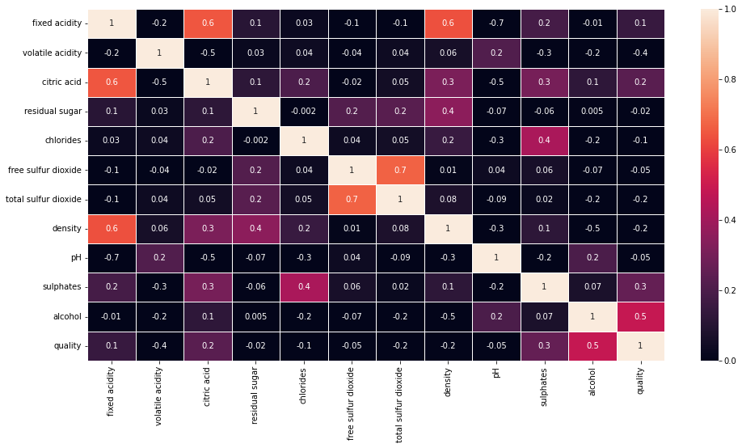

```python
plt.figure(figsize=(16,8))
sns.heatmap(df_sample.corr(), annot=True,linewidth=.5, fmt='.1g', vmin=0)
plt.show()
```

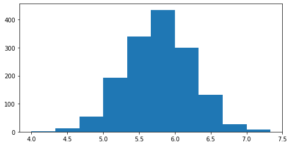

```python
plt.figure(figsize=(8, 4))
plt.hist(df_sample['quality'])
plt.show();
```

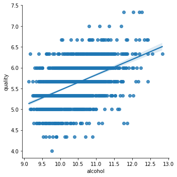

```python
sns.lmplot(x = 'alcohol', y = 'quality',data = df_sample)
plt.show()
```

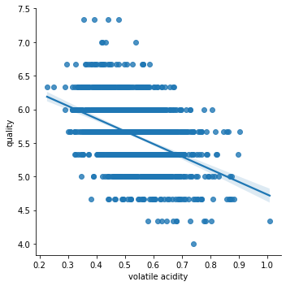

```python
sns.lmplot(x='volatile acidity',y='quality',data=df_sample)
plt.show()
```

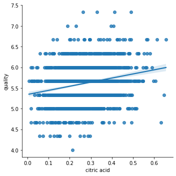

```python
sns.lmplot(x='citric acid',y='quality',data=df_sample)
plt.show()
```

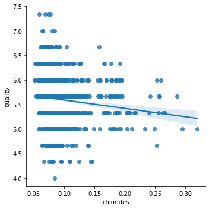

```python
sns.lmplot(x='chlorides',y='quality',data=df_sample)
plt.show()
```

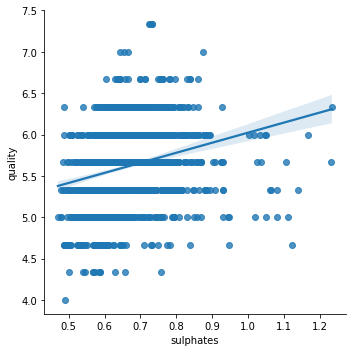

```python
sns.lmplot(x='sulphates',y='quality',data=df_sample)
plt.show()
```

```python
df_sample = df_sample.rename(columns={'citric acid': 'citric_acid', 'volatile acidity': 'volatile_acidity'})
```

## Etude d'un modèle par régression linéaire

```python
y = df_sample['quality']
X = df_sample[['alcohol', 'sulphates', 'citric_acid', 'volatile_acidity']]
```

```python
X_train, X_test, y_train, y_test = train_test_split(X, y, test_size=0.3, random_state = 6)
```

Stratégie minmaxscaler (mms)

```python
pipeline = Pipeline([
    ('imputer', SimpleImputer(strategy="median")),
    ('minmax_scaler', MinMaxScaler())
])
```

```python
preprocessor = ColumnTransformer([
    ('transformer', pipeline, list(X))
])
```

```python
pipeline_workflow = make_pipeline(preprocessor, LinearRegression())
```

```python
pipeline_workflow
```

```
Pipeline(steps=[('columntransformer',
                 ColumnTransformer(transformers=[('transformer',
                                                  Pipeline(steps=[('imputer',
                                                                   SimpleImputer(strategy='median')),
                                                                  ('minmax_scaler',
                                                                   MinMaxScaler())]),
                                                  ['alcohol', 'sulphates',
                                                   'citric_acid',
                                                   'volatile_acidity'])])),
                ('linearregression', LinearRegression())])
```

```python
pipeline_workflow.fit(X_train, y_train)
```

```
Pipeline(steps=[('columntransformer',
                 ColumnTransformer(transformers=[('transformer',
                                                  Pipeline(steps=[('imputer',
                                                                   SimpleImputer(strategy='median')),
                                                                  ('minmax_scaler',
                                                                   MinMaxScaler())]),
                                                  ['alcohol', 'sulphates',
                                                   'citric_acid',
                                                   'volatile_acidity'])])),
                ('linearregression', LinearRegression())])
```

```python
pipeline_workflow.score(X_test, y_test)
```

```
0.366842530354236
```

## Etude d'un modèle par Ridge

```python
pipeline_workflow_ridge = make_pipeline(preprocessor, Ridge())
```

```python
pipeline_workflow_ridge.fit(X_train, y_train)
```

```
Pipeline(steps=[('columntransformer',
                 ColumnTransformer(transformers=[('transformer',
                                                  Pipeline(steps=[('imputer',
                                                                   SimpleImputer(strategy='median')),
                                                                  ('minmax_scaler',
                                                                   MinMaxScaler())]),
                                                  ['alcohol', 'sulphates',
                                                   'citric_acid',
                                                   'volatile_acidity'])])),
                ('ridge', Ridge())])
```

```python
pipeline_workflow_ridge.score(X_test, y_test)
```

```
0.366345830088015
```

Test de cross-validation

```python
cross_val_score(pipeline_workflow_ridge, X_train, y_train, cv=5)
```

```
array([0.28794149, 0.38918108, 0.36379747, 0.36336271, 0.33021903])
```

```python
cross_val_score(pipeline_workflow_ridge, X_train, y_train, cv=5, scoring='r2').mean()
```

```
0.346900354980075
```

```python
y_pred = pipeline_workflow_ridge.predict(X_test)
```

Condition de normalité des erreurs

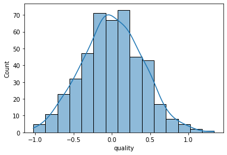

```python
residus = y_pred - y_test
sns.histplot(residus, bins=15, kde=True)
plt.show()
```

Test homoscédasticité

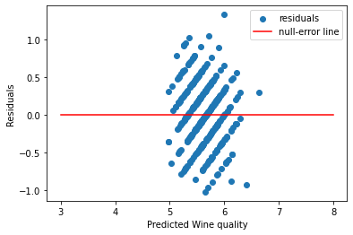

```python
plt.scatter(y_pred, residus, label = 'residuals')
plt.plot([3,8], [0,0], c ='r', label = 'null-error line')
plt.xlabel('Predicted Wine quality')
plt.ylabel('Residuals')
plt.legend()
plt.show()
```

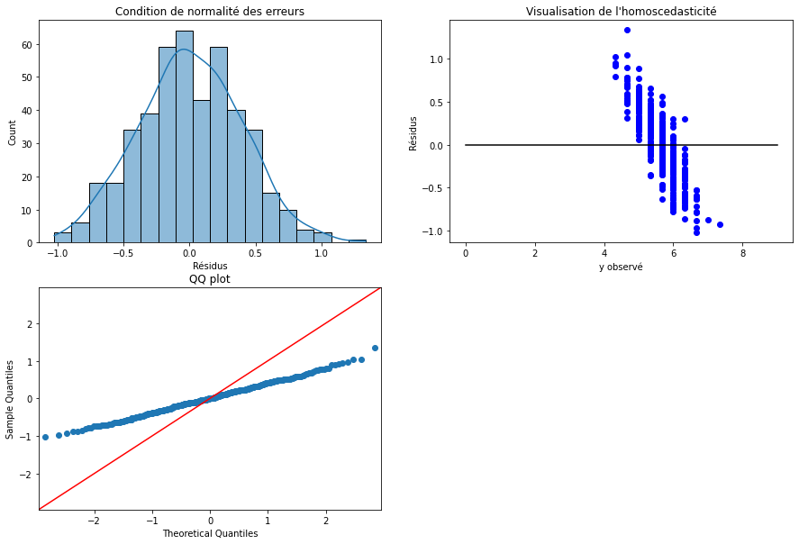

```python
fig, ((ax1,ax2),
      (ax3,ax4)) = plt.subplots(figsize=(15, 10),nrows=2, ncols=2)

ax1.set_title('Condition de normalité des erreurs')
sns.histplot(residus, ax = ax1, kde = True)
ax1.set_xlabel('Résidus')


ax2.set_title("Visualisation de l'homoscedasticité")
ax2.scatter(y_test, residus, c="blue")
ax2.plot(np.array(range(0,10)),np.zeros(10), c="black")
ax2.set_xlabel('y observé')
ax2.set_ylabel('Résidus')


ax3.set_title('QQ plot')
sm.qqplot(residus, line='45', ax= ax3)

ax4.set_visible(False)

plt.show();
```

Sauvegarde du modèle au format pickle

```python
model = pipeline_workflow_ridge.fit(X,y)
```

```python
pickle.dump(model, open('model.pkl', 'wb'))
```